# R básico para ciencia de datos - Clase 2

Ph D. Stephanie Hereira-Pacheco

Universidad Autónoma de Tlaxcala

2026-05-20

## Datos y funciones en R — Clase 2

- *Dataframes*: qué son y cómo explorarlos
- **El operador `$`**
- **Subconjuntos básicos**
- **Funciones básicas útiles**
- **Tratando con datos `NA`**
- **Importando datos a R**
- **Ejercicios**

## ¿Qué es un *dataframe*?

La forma más común de almacenar datos en R. Piénsenlo como una **tabla de Excel**:

- Cada **fila** = una observación
- Cada **columna** = una variable
- Puede mezclar distintos tipos de datos (números, texto, factores)

```r
data(ToothGrowth)
str(ToothGrowth)
```

```
'data.frame':   60 obs. of  3 variables:
 $ len : num  4.2 11.5 7.3 5.8 6.4 10 11.2 11.2 5.2 7 ...
 $ supp: Factor w/ 2 levels "OJ","VC": 2 2 2 2 2 2 2 2 2 2 ...
 $ dose: num  0.5 0.5 0.5 0.5 0.5 0.5 0.5 0.5 0.5 0.5 ...
```

`str()` nos muestra la estructura: 60 filas, 3 variables.

## Exploración básica del *dataframe*

```r
head(ToothGrowth)      # primeras 6 filas
```

```
   len supp dose
1  4.2   VC  0.5
2 11.5   VC  0.5
3  7.3   VC  0.5
4  5.8   VC  0.5
5  6.4   VC  0.5
6 10.0   VC  0.5
```

```r
dim(ToothGrowth)       # filas y columnas
```

```
[1] 60  3
```

**Tip**

`head()`, `dim()` y `str()` son los tres primeros comandos que siempre debes usar cuando tienes datos nuevos.

## Crear un *dataframe* propio

```r
estudiantes <- data.frame(
  nombre = c("Ana", "Clara", "Sofy"),
  nota   = c(10, 9, 7),
  grupo  = c("A", "A", "B"))

estudiantes
```

```
  nombre nota grupo
1    Ana   10     A
2  Clara    9     A
3   Sofy    7     B
```

```r
colnames(estudiantes)   # nombres de las columnas
```

```
[1] "nombre" "nota"   "grupo"
```

## El operador `$`

Es la forma más directa de acceder a **una columna**:

```r
estudiantes$nombre
```

```
[1] "Ana"   "Clara" "Sofy"
```

```r
estudiantes$nota
```

```
[1] 10  9  7
```

**Tip**

En RStudio: escribe `estudiantes$` y presiona **Tab** — aparecen los nombres de las columnas automáticamente.

## `$` también funciona para crear columnas

```r
estudiantes$aprobado <- c("Sí", "Sí", "Sí")
estudiantes
```

```
  nombre nota grupo aprobado
1    Ana   10     A       Sí
2  Clara    9     A       Sí
3   Sofy    7     B       Sí
```

Y para modificar valores:

```r
estudiantes$nota[2] <- 10
estudiantes
```

```
  nombre nota grupo aprobado
1    Ana   10     A       Sí
2  Clara   10     A       Sí
3   Sofy    7     B       Sí
```

## Subconjuntos: por posición con `[`

La sintaxis es `datos[filas, columnas]`:

```r
estudiantes[1, ]        # primera fila completa
```

```
  nombre nota grupo aprobado
1    Ana   10     A       Sí
```

```r
estudiantes[, 2]        # segunda columna completa
```

```
[1] 10 10  7
```

```r
estudiantes[1, 2]       # fila 1, columna 2
```

```
[1] 10
```

## Subconjuntos: por nombre de columna

```r
estudiantes[c("nombre", "nota")]
```

```
  nombre nota
1    Ana   10
2  Clara   10
3   Sofy    7
```

```r
estudiantes[, -1]       # excluir la primera columna
```

```
  nota grupo aprobado
1   10     A       Sí
2   10     A       Sí
3    7     B       Sí
```

**Note**

El signo **`-`** delante del número excluye esa posición en lugar de seleccionarla.

## Funciones básicas: `sort` y `order`

```r
sort(estudiantes$nota)                        # de menor a mayor
```

```
[1]  7 10 10
```

```r
sort(estudiantes$nota, decreasing = TRUE)     # de mayor a menor
```

```
[1] 10 10  7
```

```r
order(estudiantes$nota)    # devuelve las posiciones en orden
```

```
[1] 3 1 2
```

**Note**

`sort()` reordena los **valores**. `order()` devuelve las **posiciones** — útil para ordenar tablas completas.

## Funciones básicas: `max`, `min`, `mean`, `sum`

```r
max(estudiantes$nota)
```

```
[1] 10
```

```r
min(estudiantes$nota)
```

```
[1] 7
```

```r
mean(estudiantes$nota)
```

```
[1] 9
```

```r
sum(estudiantes$nota)
```

```
[1] 27
```

## Funciones básicas: `which.max` y `which.min`

```r
which.max(estudiantes$nota)                    # posición del máximo
```

```
[1] 1
```

```r
estudiantes[which.max(estudiantes$nota), ]     # fila completa
```

```
  nombre nota grupo aprobado
1    Ana   10     A       Sí
```

```r
which.min(estudiantes$nota)                    # posición del mínimo
```

```
[1] 3
```

```r
estudiantes[which.min(estudiantes$nota), ]     # fila completa
```

```
  nombre nota grupo aprobado
3   Sofy    7     B       Sí
```

## Tratando con datos `NA`

`NA` significa **dato faltante** (*Not Available*). Aparece cuando no hay información.

```r
notas_con_faltantes <- c(10, NA, 8, 9, NA, 7)
is.na(notas_con_faltantes)       # ¿cuáles son NA?
```

```
[1] FALSE  TRUE FALSE FALSE  TRUE FALSE
```

```r
sum(is.na(notas_con_faltantes))  # ¿cuántos NA hay en total?
```

```
[1] 2
```

## NA: efecto en cálculos

```r
mean(notas_con_faltantes)                  # NA contamina el resultado
```

```
[1] NA
```

```r
mean(notas_con_faltantes, na.rm = TRUE)    # ignorar los NA
```

```
[1] 8.5
```

**Important**

Casi todas las funciones de R tienen el argumento `na.rm = TRUE` para ignorar los valores faltantes al calcular.

## NA: eliminar filas con datos faltantes

```r
mi_data <- data.frame(
  alumno = c("Ana", "Luis", "Sofy", "Pedro"),
  nota   = c(9, NA, 8, NA))

mi_data[!is.na(mi_data$nota), ]  # filas sin NA
```

```
  alumno nota
1    Ana    9
3   Sofy    8
```

```r
na.omit(mi_data)                  # equivalente
```

```
  alumno nota
1    Ana    9
3   Sofy    8
```

## Ejercicios

**Note**

Trabajaremos con el dataset `iris`. Cárgalo con: `data(iris)`

1. Usa `str()`, `head()` y `dim()` para explorar `iris`. ¿Cuántas filas y columnas tiene?
2. Accede a la columna `Sepal.Length` con `$`. ¿Cuál es su valor máximo y mínimo?
3. ¿Qué fila tiene el pétalo más largo (`Petal.Length`)? Usa `which.max()`.

## Ejercicios (cont.)

4. Crea una nueva columna `razon` en `iris` calculando `Sepal.Length / Petal.Length`.
5. Ordena `razon` de mayor a menor con `sort()`. ¿Cuál es el valor más alto?
6. ¿En qué posición está el valor mínimo de `razon`? Usa `which.min()` y accede a esa fila completa.

## Soluciones: ejercicios 1, 2 y 3

**1.** Explorar `iris`:

```r
str(iris)
```

```
'data.frame':   150 obs. of  5 variables:
 $ Sepal.Length: num  5.1 4.9 4.7 4.6 5 5.4 4.6 5 4.4 4.9 ...
 $ Sepal.Width : num  3.5 3 3.2 3.1 3.6 3.9 3.4 3.4 2.9 3.1 ...
 $ Petal.Length: num  1.4 1.4 1.3 1.5 1.4 1.7 1.4 1.5 1.4 1.5 ...
 $ Petal.Width : num  0.2 0.2 0.2 0.2 0.2 0.4 0.3 0.2 0.2 0.1 ...
 $ Species     : Factor w/ 3 levels "setosa","versicolor",..: 1 1 1 1 1 1 1 1 1 1 ...
```

```r
dim(iris)    # 150 filas, 5 columnas
```

```
[1] 150   5
```

**2.** Máximo y mínimo de `Sepal.Length`:

```r
max(iris$Sepal.Length)
```

```
[1] 7.9
```

```r
min(iris$Sepal.Length)
```

```
[1] 4.3
```

## Soluciones: ejercicio 3

**3.** Fila con el pétalo más largo:

```r
which.max(iris$Petal.Length)
```

```
[1] 119
```

```r
iris[which.max(iris$Petal.Length), ]
```

```
    Sepal.Length Sepal.Width Petal.Length Petal.Width   Species
119          7.7         2.6          6.9         2.3 virginica
```

## Soluciones: ejercicios 4, 5 y 6

**4.** Nueva columna `razon`:

```r
iris$razon <- iris$Sepal.Length / iris$Petal.Length
head(iris$razon)
```

```
[1] 3.642857 3.500000 3.615385 3.066667 3.571429 3.176471
```

**5.** Ordenar de mayor a menor:

```r
sort(iris$razon, decreasing = TRUE) |> head()
```

```
[1] 4.833333 4.600000 4.230769 4.166667 4.153846 3.928571
```

## Soluciones: ejercicio 6

**6.** Posición del mínimo y fila completa:

```r
which.min(iris$razon)
```

```
[1] 101
```

```r
iris[which.min(iris$razon), ]
```

```
    Sepal.Length Sepal.Width Petal.Length Petal.Width   Species razon
101          6.3         3.3            6         2.5 virginica  1.05
```

## Importando datos a R

Los formatos más comunes son:

**CSV** (separado por comas):

```
species,body_mass_g,sex
Adelie,3750,male
Gentoo,5700,male
```

**TXT** (separado por tabulación):

```
species    body_mass_g   sex
Adelie     3750          male
Gentoo     5700          male
```

**Puntos importantes:**

- La **primera fila** siempre es el encabezado
- Sin celdas vacías ni colores
- Sin fórmulas de Excel
- Nombres de columna sin espacios

## Directorio de trabajo

Antes de importar, debemos saber en qué carpeta estamos:

```r
getwd()                      # ver el directorio actual
setwd("C:/mi_carpeta")       # cambiar el directorio
```

**Tip**

La opción más sencilla: guardar el archivo en la misma carpeta que el script y usar solo el nombre del archivo. Si usan **Proyectos de R** (`.Rproj`), el directorio se configura solo.

## Paquetes para importar datos

**`readr`** — para archivos de texto (CSV, TSV, TXT):

| Función | Separador | Extensión |
| --- | --- | --- |
| `read_csv` | Coma `,` | csv |
| `read_csv2` | Punto y coma `;` | csv |
| `read_tsv` | Tabulación | tsv, txt |
| `read_delim` | El que tú definas | cualquiera |

**`readxl`** — para archivos de Excel:

| Función | Formato |
| --- | --- |
| `read_excel` | Detecta automáticamente `.xls` y `.xlsx` |
| `read_xlsx` | Solo `.xlsx` |

## Sintaxis: importar CSV

Con **R base** (sin paquetes extra):

```r
datos <- read.csv("mi_archivo.csv")
datos <- read.csv("mi_archivo.csv", sep = ";")  # si usa punto y coma
```

Con el paquete **`readr`** (recomendado):

```r
library(readr)
datos <- read_csv("mi_archivo.csv")
datos <- read_csv2("mi_archivo.csv")   # si usa punto y coma
```

**Note**

`read_csv()` (con guión bajo) es más rápida y consistente que `read.csv()` (con punto) de R base.

## Sintaxis: importar Excel

```r
library(readxl)
datos <- read_excel("mi_archivo.xlsx")
datos <- read_excel("mi_archivo.xlsx", sheet = "Hoja2")  # hoja específica
datos <- read_excel("mi_archivo.xlsx", sheet = 2)        # por número
```

**Tip**

Para Excel con varias hojas, usa el argumento `sheet =` con el nombre o número de la hoja.

## Import Dataset: la opción visual

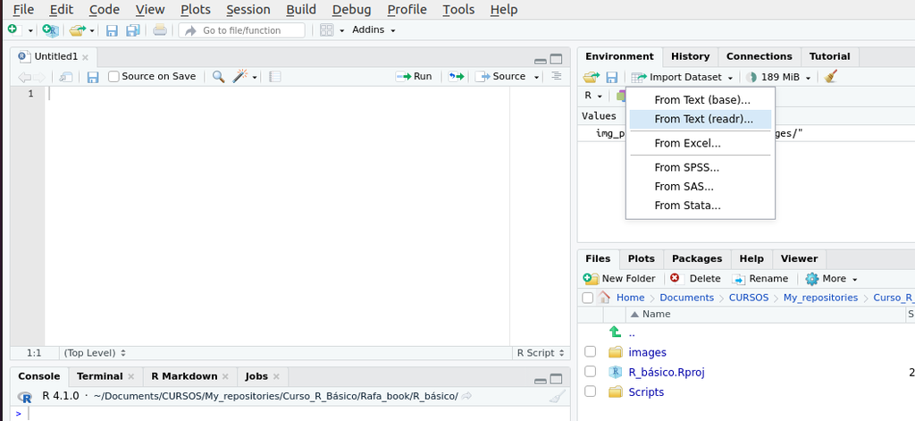

## Import Dataset: cómo usarlo

Panel **Environment → Import Dataset**

- Selecciona el tipo: **From Text (readr)** para CSV/TXT · **From Excel** para xlsx
- Vista previa de los datos antes de importar
- Ajusta opciones (separador, encabezado, tipos de columna)
- **Genera el código automáticamente** — solo copiarlo al script

**Tip**

Este es el método más fácil para empezar. Una vez que copies el código al script, no necesitas volver a usar la interfaz.

## Tips para preparar archivos Excel

[figure not shown]

## Tips para preparar archivos Excel

- Primera fila: **nombres de columnas** — sin espacios ni caracteres especiales
- Una observación por fila, una variable por columna
- Sin celdas combinadas ni filas de totales al final
- Sin colores, negritas ni formatos visuales
- Sin fórmulas — solo valores

**Tip**

Guardar el Excel como `.csv` (*Archivo → Guardar como → CSV UTF-8*) antes de importar es la opción más sencilla y confiable.

## ¡Practiquemos juntos!

Tenemos el archivo `datos_practica.csv` en nuestra carpeta de trabajo. Así lo cargamos:

```r
library(readr)
pinguinos <- read_csv("datos_practica.csv")
head(pinguinos)
```

```
# A tibble: 6 × 7
  species island  culmen_length_mm culmen_depth_mm flipper_length_mm body_mass_g
  <chr>   <chr>              <dbl>           <dbl>             <dbl>       <dbl>
1 Adelie  Torger…             39.1            18.7               181        3750
2 Adelie  Torger…             39.5            17.4               186        3800
3 Adelie  Torger…             40.3            18                 195        3250
4 Adelie  Torger…             NA              NA                  NA          NA
5 Adelie  Torger…             36.7            19.3               193        3450
6 Adelie  Torger…             39.3            20.6               190        3650
# ℹ 1 more variable: sex <chr>
```

## ¡Practiquemos juntos! (cont.)

```r
str(pinguinos)
```

```
spc_tbl_ [344 × 7] (S3: spec_tbl_df/tbl_df/tbl/data.frame)
 $ species          : chr [1:344] "Adelie" "Adelie" "Adelie" "Adelie" ...
 $ island           : chr [1:344] "Torgersen" "Torgersen" "Torgersen" "Torgersen" ...
 $ culmen_length_mm : num [1:344] 39.1 39.5 40.3 NA 36.7 39.3 38.9 39.2 34.1 42 ...
 $ culmen_depth_mm  : num [1:344] 18.7 17.4 18 NA 19.3 20.6 17.8 19.6 18.1 20.2 ...
 $ flipper_length_mm: num [1:344] 181 186 195 NA 193 190 181 195 193 190 ...
 $ body_mass_g      : num [1:344] 3750 3800 3250 NA 3450 ...
 $ sex              : chr [1:344] "MALE" "FEMALE" "FEMALE" NA ...
 - attr(*, "spec")=
  .. cols(
  ..   species = col_character(),
  ..   island = col_character(),
  ..   culmen_length_mm = col_double(),
  ..   culmen_depth_mm = col_double(),
  ..   flipper_length_mm = col_double(),
  ..   body_mass_g = col_double(),
  ..   sex = col_character()
  .. )
 - attr(*, "problems")=<externalptr>
```

```r
dim(pinguinos)
```

```
[1] 344   7
```

## Exploremos los datos

```r
colnames(pinguinos)
```

```
[1] "species"           "island"            "culmen_length_mm"
[4] "culmen_depth_mm"   "flipper_length_mm" "body_mass_g"
[7] "sex"
```

```r
head(pinguinos, 10)
```

```
# A tibble: 10 × 7
   species island culmen_length_mm culmen_depth_mm flipper_length_mm body_mass_g
   <chr>   <chr>             <dbl>           <dbl>             <dbl>       <dbl>
 1 Adelie  Torge…             39.1            18.7               181        3750
 2 Adelie  Torge…             39.5            17.4               186        3800
 3 Adelie  Torge…             40.3            18                 195        3250
 4 Adelie  Torge…             NA              NA                  NA          NA
 5 Adelie  Torge…             36.7            19.3               193        3450
 6 Adelie  Torge…             39.3            20.6               190        3650
 7 Adelie  Torge…             38.9            17.8               181        3625
 8 Adelie  Torge…             39.2            19.6               195        4675
 9 Adelie  Torge…             34.1            18.1               193        3475
10 Adelie  Torge…             42              20.2               190        4250
# ℹ 1 more variable: sex <chr>
```

## Exploremos los datos: estadísticos básicos

```r
max(pinguinos$body_mass_g, na.rm = TRUE)
```

```
[1] 6300
```

```r
min(pinguinos$body_mass_g, na.rm = TRUE)
```

```
[1] 2700
```

```r
mean(pinguinos$body_mass_g, na.rm = TRUE)
```

```
[1] 4201.754
```

## Exploremos los datos: ¿cuántos NA hay?

```r
sum(is.na(pinguinos))                      # total en toda la tabla
```

```
[1] 18
```

```r
sum(is.na(pinguinos$body_mass_g))          # solo en una columna
```

```
[1] 2
```

## Exploremos los datos: ¿cuál es el más pesado?

```r
which.max(pinguinos$body_mass_g)
```

```
[1] 238
```

```r
pinguinos[which.max(pinguinos$body_mass_g), ]
```

```
# A tibble: 1 × 7
  species island culmen_length_mm culmen_depth_mm flipper_length_mm body_mass_g
  <chr>   <chr>             <dbl>           <dbl>             <dbl>       <dbl>
1 Gentoo  Biscoe             49.2            15.2               221        6300
# ℹ 1 more variable: sex <chr>
```

## Referencias

- Irizarry, R.A. (2019). *Introduction to Data Science*. Leanpub. rafalab.dfci.harvard.edu/dsbook
- Wickham, H. & Grolemund, G. (2017). *R for Data Science*. O’Reilly. r4ds.had.co.nz
- Bosco Mendoza, J. (2019). *R para principiantes*. bookdown.org/jboscomendoza/r-principiantes4
- CRAN — Comprehensive R Archive Network: cran.r-project.org
- RStudio Education: education.rstudio.com

R básico para ciencia de datos · UAT 2026